# DLBook_ch06

## Chapter 6

#### Deep Feed Forward Networks aka FFNN, MLP

Depth = Number of Layers

Width = Number of Neurons in a Layer

output layer = Final layer

Training Data specify directly what the output layer must do, but not what each hidden layers do - the learning algorithm must decide how to use these layers

"feedforward networks as function approximation machines that are designed to achieve statistical generalization"

### Linear Models

Linear models are appealing because they may be fit efficiently and reliably, either in closed form or with convex optimization.

To extend linear models to represent nonlinear functions of x --> apply Kernel Trick

How to choose the mapping $\phi$ that provides a new representation for x

1. Use a very generic $\phi$ - like RBF Kernel, but generalizes poorly, and cannot solve advanced problems
1. Manually handcraft $\phi$
1. Use Deep Learning to learn $\phi$  
   $ y = f(x;\theta,w) = \phi(x;\theta)w $  
   can have advantage of both 1 and 2  
   #1. generic - choose a very broad family $\phi(x;\theta)$  
   #2. hand-craft - find right general function family

## 6.1 Example: Learning XOR

Linear model cannot represent XOR

Simple FFNN: $ h = f^{(1)}(x; W,c) $  
$ y = f^({2)}(h;w,b) $  
$ f(x;W,c,w,b) = f^{(2)}(f^{(1)}(x)) $

affine transformation from a vector $x$ to a vector $h$  
activation function $g$ - element-wise activation

$ f(x;W,c,w,b) = w^{T}max[0,W^{T}x+c] + b $

Non-linear activation function (ReLU) mapps both $ x = [1,0]^{T} $ and $x=[0,1]^{T} $ to a single point in feature space, $ h = [1,0]^{T} $

## 6.2 Gradient-based Learning

Non-linearity of a NN causes most interesting loss functions to become non-convex

Stochastic Gradient Descent applied to non-convex loss functions has no Convergence guarantee, and is sensitive to the values of the initial parameters

### 6.2.1 Cost Functions

1. $\textbf{ Negative Log Likelihood aka Cross Entropy between Training Data and Model Distribution}$  
   $ J(\theta) = -E_{x,y ~ p_{data}} logp_{model}(y|x) $  
   Advantage of this approach is specifying a model $p(y|x)$ automatically determines a cost function log $p(y|x)$  
   Also, the log undoes the exponent of some output units and prevent saturating functions.
2. $\textbf{ Functional }$  
   Instead of learning a full probability distribution $p(y|x;\theta)$ we often want to learn just one conditional statistic of $y$ given $x$  
   A Functional is a mapping from functions to real numbers.  
   We can think of learning as choosing a function rather than merely choosing a set of parameters  
   For example, we can design the cost functional to have its minimum lie on the function that maps $x$ to the expected value of $y$ given $x$.  
   Unfortunately, mean squared error and mean absolute error often lead to poor results when used with gradient-based optimization.

```python
import numpy as np
import matplotlib.pyplot as plt
%matplotlib inline
%config InlineBackend.figure_format = 'retina'

x = np.linspace(-100,100, 10000)
```

```python
def softmax(x):
    """Compute softmax values for each sets of scores in x."""
    e_x = np.exp(x - np.max(x))
    return e_x / e_x.sum()

for i in x:
    softmax_i = softmax(x)
```

```
Text(0.5,1,'Softmax Function')
```

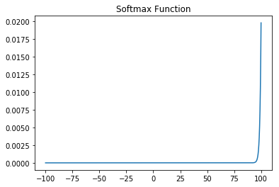

```python
plt.plot(x, softmax_i)
plt.title('Softmax Function')
```

```python
def sigmoid(x):
      return 1 / (1 + np.exp(-x))
for i in x:
    sigmoid_i = sigmoid(x)
```

```
Text(0.5,1,'Sigmoid Function')
```

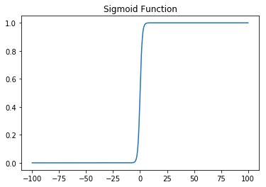

```python
plt.plot(x, sigmoid_i)
plt.title('Sigmoid Function')
```

$ log\,softmax(z)_i \, = \, z_i \, - \, log \sum_{j}^{} exp(z_j) $

First term cannot saturate, and the learning can proceed even when the second term becomes very small.

When maximizing Log-Likelihood, first term encourages $z_i$ to be pushed up

While the second term encourages all of $z$ to be pushed down

$log \sum_{j}^{} exp(z_j)$ can be roughly approximated by $max_j\,z_j$

objective functions that do not use a log to undo the exp of the softmax fail to learn when the argument to the exp becomes very negative, causing the gradient to vanish. In particular, squared error is a poor loss function for softmax units, and can fail to train the model to change its output, even when the model makes highly confident incorrect predictions

Softmax: At the extreme (when the difference between the maximal a i and the others is large in magnitude) it becomes a form of winner-take-all (one of the outputs is nearly 1 and the others are nearly 0).

Name: The softmax function thus provides a “softened” version of the argmax

In general, if we define a conditional distribution $p(y\,|\,x;\,\theta)$, the principle of maximum likelihood suggests we use $-log\,p(y\,|\,x;\,\theta)$ as our cost function

In general, we can think of the neural network as representing a function $f(x;\theta)$

$f(x;\theta)\,=\,w$ provides the parameters for a distribution over $y$.

Our loss function can then be interpreted as $-log\,p(y;w(x))$